# 01- Prior & Posterior Probability Given by a Classifier

Yao Siyuan

August 10, 2017

## Oversampling

Given an imbalanced sample set, we can resample the set to create a balance one, which will bring some extra benefits for most classifiers.

However, it brings some problems for model prediction for the predicted probability changes after the resampling. If we really cares the probabilities, we need transform the posterior probability to the prior probability.

This page will focus on this topic.

## Methodology

Denote the original ratio of the minority class as $r_1$, the ratio after oversampling as $r_2$, the number of minorities as $x$, and the number of mojorities $y$.

$$\frac{x}{x + y} = r_1$$
$$\frac{kx}{kx + y} = r_2$$

By solving the equations, we can get

$$k = \frac{r_2(1 - r_1)}{r_1(1 - r_2)}$$

For the same reason, if a sample’s prior probability to be a minority before oversampling is $p_1$, and the posterior probability to be a minority after oversampling is $p_2$, then, the same relation holds,

$$k = \frac{p_2(1 - p_1)}{p_1(1 - p_2)}$$

By solving the equation, we can get

$$p_1 = \frac{p_2}{k(1 - p_2) + p_2}$$

## R Function

The R function for the adjustment is as following.

```r
prior_prob <- function(posterior, r1 = 0.05, r2 = 0.5) {
    k <- r2 * (1 - r1) / (r1 - r1 * r2)
    posterior / (k * (1 - posterior) + posterior)
}
```

Some example:

1. If $r_1$ = 5%, $r_2$ = 50%, then

   ```
   $p_2$ = 30% implies $p_1$ = 0.0220588

   $p_2$ = 50% implies $p_1$ = 0.05

   $p_2$ = 70% implies $p_1$ = 0.109375
   ```

2. Given $r_1$ = 8%, $r_2$ = 50%, the curve below shows the relationship between the posterior probability and the prior probability.

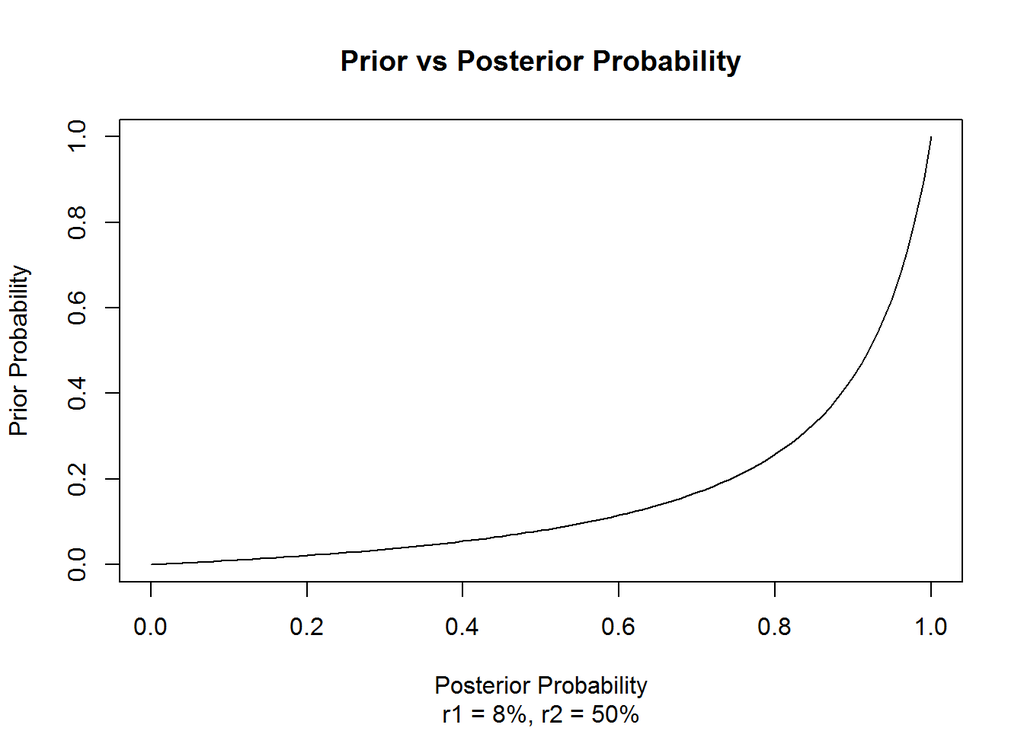

```r
posterior <- seq(0, 1, by = 0.01)
prior <- prior_prob(posterior, r1 = 0.08, r2 = 0.5)

plot(posterior, prior, type = 'l',
     xlab = 'Posterior Probability',
     ylab = 'Prior Probability',
     main = 'Prior vs Posterior Probability',
     sub = 'r1 = 8%, r2 = 50%')
```